# Connectivity deep biosphere microbes

George Westmeijer

25/11/2021

```r
library(tidyverse)
```

## Read files

The sequence table (“seqtab.tsv”) is stored in long format. Samples with less than 1000 reads have been removed. The sample metadata (‘smd.tsv’) contains the environment of the sample (environment) and allows grouping by replicates.

```r
smd <- read_tsv('smd.tsv', col_types = cols(.default = col_character())) %>%
  # Some samples have been filtered out above
  mutate(env = factor(env,
                      levels = c('Baltic surface seawater',
                                 'Baltic benthic seawater',
                                 'Upper sediment',
                                 'Lower sediment',
                                 'Upper soil groundwater',
                                 'Lower soil groundwater',
                                 'Meteoric groundwater',
                                 'Modern marine groundwater',
                                 'Old saline groundwater'))) %>%
  group_by(env) %>% add_tally() %>% ungroup()

tax <- read_tsv('taxonomy.tsv', col_types = cols(.default = col_character()))

seqtab <- read_tsv('seqtab.tsv', col_types = cols(.default = col_character(), count = col_integer())) %>%
  # Filter out samples with less than 1000 reads
  group_by(sample) %>% filter(sum(count) > 1000) %>%
  # Calculate relative abundance within sample
  mutate(relab = count / sum(count)) %>% ungroup() %>%
  # Average the relab within an environment by dividing by the total
  inner_join(smd, by = 'sample') %>%
  group_by(env) %>% mutate(relab = relab / sum(relab)) %>% ungroup() %>%
  select(seqid, sample, count, relab) -> seqtab

chemistry <- read_tsv('chemistry.txt', col_types = cols(.default = col_double(), replicate = col_character())) %>%
  mutate(Cl = Cl / 1000, EC = EC / 100) %>%
  gather(parameter, value, -1) %>%
  na.omit()
```

Define themes to use throughout the manuscript

```r
theme_tidy <- function() {
  theme(
    axis.title.x = element_text(colour = "black", size = 8),
    axis.title.y = element_text(colour = "black", size = 8),
    axis.text.x = element_text(colour = "black", size = 8),
    axis.text.y = element_text(colour = "black", size = 8),
    legend.text = element_text(colour = "black", size = 8),
    strip.background = element_blank(),
    strip.placement = "outside",
    strip.text = element_text(colour = "black", size = 8, hjust = 0.5),
    panel.grid = element_blank(),
    legend.position = "bottom",
    aspect.ratio = 1.0,
    plot.background = element_blank(),
    panel.background = element_blank(),
    panel.border = element_rect(colour = "black", size = 0.5, fill = NA),
    legend.title = element_blank(),
    legend.box.background = element_blank(),
    legend.key = element_blank()
  )
}

theme_barplot <- function() {
  theme(
    axis.title.x = element_text(colour = "black", size = 8),
    axis.title.y = element_text(colour = "black", size = 8),
    axis.text.x = element_text(colour = "black", size = 8),
    axis.text.y = element_text(colour = "black", size = 8, margin = margin(0,-5,0,0, unit = 'mm')),
    legend.text = element_text(colour = "black", size = 8),
    strip.background = element_blank(),
    panel.grid = element_blank(),
    legend.position = "bottom",
    aspect.ratio = 0.7,
    strip.text = element_text(colour = "black", size = 8, hjust = 0.5),
    plot.background = element_blank(),
    panel.background = element_blank(),
    legend.title = element_blank(),
    legend.box.background = element_blank(),
    legend.key = element_blank(),
    legend.spacing.x = unit(0.5, 'mm'),
    panel.border = element_blank(),
    legend.key.size = unit(4.5, "mm"),
    legend.box.spacing = unit(1, 'mm'),
    axis.ticks.y = element_blank()
  )
}
```

```r
barplot <- function(asvs = seqtab, meta = smd, taxonomy = tax, taxlevel = "phylum", n = 11) {
  if (taxlevel == "phylum") {
  asvs %>%
  inner_join(meta, by = 'sample') %>%
  inner_join(taxonomy, by = "seqid") %>%
  group_by(phylum, env) %>%
  # Sum the abundance of each phylum within a sample
  summarise(relab = sum(relab), .groups = 'drop_last') %>%
  # Calculate the mean abundance of each phylum over the categories
  summarise(mean_relab = sum(relab), .groups = 'drop') %>%
  filter(!is.na(phylum) & phylum != "uncultured bacterium") %>%
  top_n(11, mean_relab) -> t

taxonomy %>%
  left_join(t %>% transmute(phylum, topphylum = phylum), by = "phylum") %>%
  replace_na(list("topphylum" = "Other")) -> taxref

asvs %>%
  inner_join(taxref, by = "seqid") %>%
  inner_join(meta, by = 'sample') %>%
  # Summarize in order to have the sum for each category and topphylum
  group_by(topphylum, env) %>%
  summarise(relab = sum(relab), .groups = 'drop') -> asvs.phylum
  return(asvs.phylum)
  }
  else if (taxlevel == "class") {
  asvs %>%
  inner_join(meta, by = 'sample') %>%
  inner_join(taxonomy, by = "seqid") %>%
  group_by(class, env) %>%
  # Sum the abundance of each phylum within a sample
  summarise(relab = sum(relab), .groups = 'drop_last') %>%
  # Calculate the mean abundance of each phylum over the categories
  summarise(mean_relab = sum(relab), .groups = 'drop') %>%
  filter(!is.na(class) & class != "uncultured bacterium") %>%
  top_n(11, mean_relab) -> t

taxonomy %>%
  left_join(t %>% transmute(class, topphylum = class), by = "class") %>%
  replace_na(list("topphylum" = "Other")) -> taxref

asvs %>%
  inner_join(taxref, by = "seqid") %>%
  inner_join(meta, by = 'sample') %>%
  # Summarize in order to have the sum for each category and topphylum
  group_by(topphylum, env) %>%
  summarise(relab = sum(relab), .groups = 'drop') -> asvs.class
  return(asvs.class)
  }
  else {
  asvs %>%
  inner_join(meta, by = 'sample') %>%
  inner_join(taxonomy, by = "seqid") %>%
  group_by(order, env) %>%
  # Sum the abundance of each phylum within a sample
  summarise(relab = sum(relab), .groups = 'drop_last') %>%
  # Calculate the mean abundance of each phylum over the categories
  summarise(mean_relab = sum(relab), .groups = 'drop') %>%
  filter(!is.na(order) & !grepl(pattern = "uncultured", x = order)) %>%
  top_n(n, mean_relab) -> t

taxonomy %>%
  left_join(t %>% transmute(order, topphylum = order), by = "order") %>%
  replace_na(list("topphylum" = "Other")) -> taxref

asvs %>%
  inner_join(taxref, by = "seqid") %>%
  inner_join(meta, by = 'sample') %>%
  # Summarize in order to have the sum for each category and topphylum
  group_by(topphylum, env) %>%
  summarise(relab = sum(relab), .groups = 'drop') -> asvs.order
  return(asvs.order)
  }
}
```

## Alpha diversity using Shannon-Weaver index

Calculate Shannon-Weaver for each sample and combine with sample metadata

```r
seqtab %>%
  select(-relab) %>%
  spread(seqid, count, fill = 0) %>% column_to_rownames('sample') %>%
  vegan::diversity() %>% as.data.frame() %>% gather(seqid, shannon, -1) %>%
  rename(shannon = 1) %>%
  rownames_to_column('sample') %>%
  inner_join(smd, by = "sample") %>%
  group_by(replicate) %>%
  mutate(meandiv = mean(shannon)) %>% ungroup() %>%
  arrange(env) -> adiv
```

Plot alpha diversity

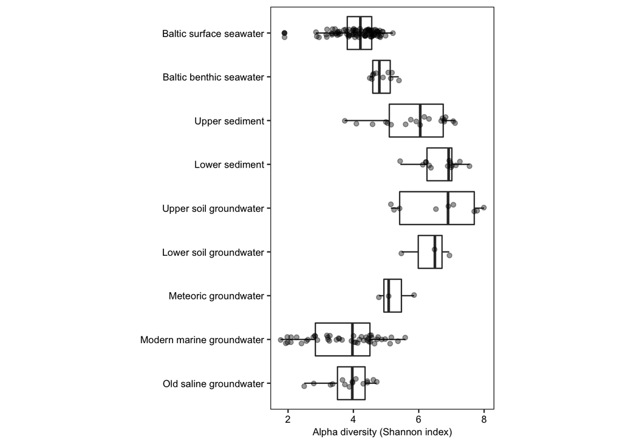

```r
ggsave("figures/fig_3a.pdf", width = 10, height = 10, units = "cm")
```

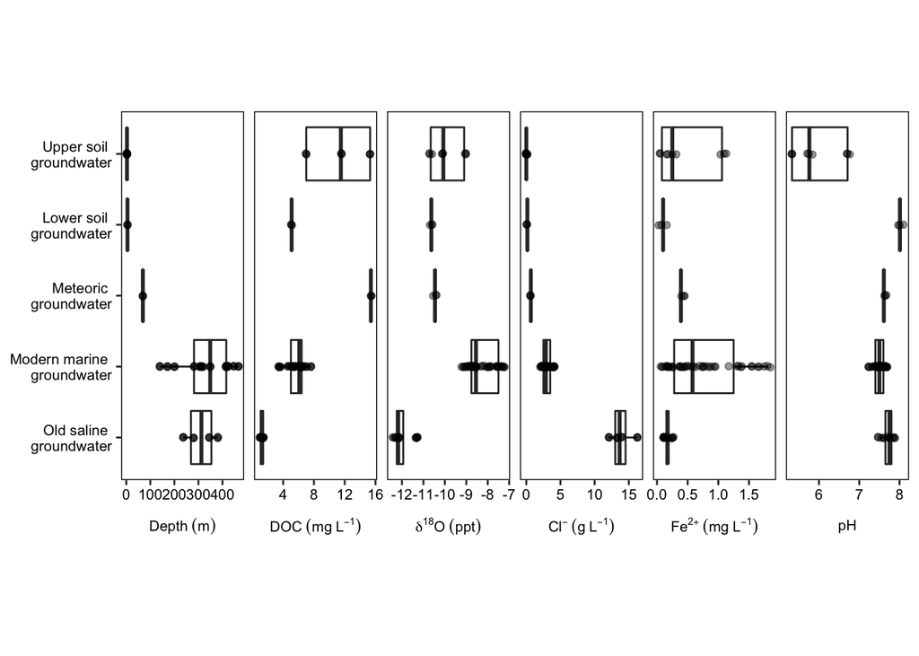

```r
chemistry %>%
  filter(parameter %in% c('O18', 'ph', 'depth', 'Cl', 'DOC', 'FEII')) %>%
  inner_join(smd, by = 'replicate') %>%
  mutate(parameter = factor(parameter, levels = c("depth","DOC","O18","Cl","FEII","ph"))) %>%
  group_by(env, parameter) %>%
  mutate(env = sub("groundwater", "\ngroundwater", env)) %>%
  ggplot(aes(x = fct_rev(fct_relevel(env, c("Upper soil \ngroundwater"))), y = value)) +
  geom_boxplot(na.rm = TRUE) +
  geom_jitter(width = 0.01, alpha = 0.4, height = 0.1, na.rm = TRUE) +
  coord_flip() +
  facet_wrap(~parameter, scales = 'free_x', nrow = 1, strip.position = 'bottom', labeller =
               as_labeller(c(
                 depth = "Depth~(m)",
                 DOC = "DOC~(mg~L^-1)",
                 Cl = 'Cl^{-phantom()}~(g~L^-1)',
                 FEII = 'Fe^{2+phantom()} ~ (mg~L^-1)',
                 O18 = 'delta^{18}*O~(ppt)',
                 ph = 'pH'), default = label_parsed)) +
  theme_tidy() + theme(aspect.ratio = 3.0,
                       strip.placement = "outside",
                       axis.title.x = element_blank(),
                       axis.title.y = element_blank())
```

```r
ggsave("figures/fig_1.pdf", width = 20, height = 10, units = "cm")
```

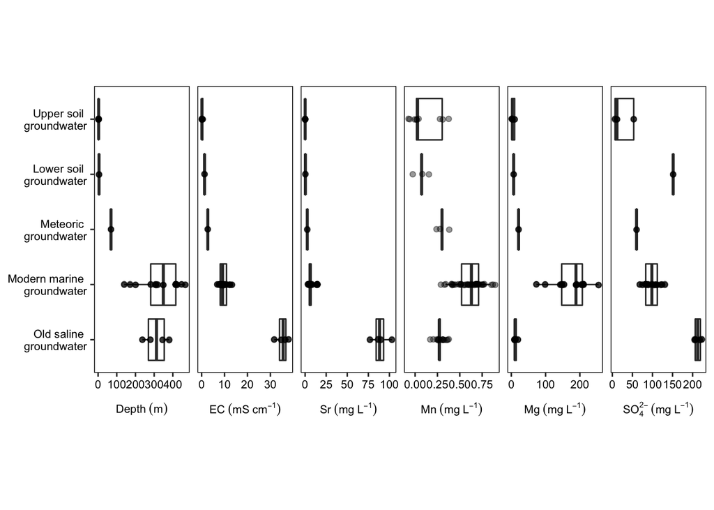

```r
chemistry %>%
  filter(parameter %in% c('depth','Mn', 'Mg', 'SO4', 'Sr', 'EC')) %>%
  inner_join(smd, by = 'replicate') %>%
  mutate(parameter = factor(parameter, levels = c("depth","EC","Sr","Mn","Mg","SO4"))) %>%
  group_by(env, parameter) %>%
  mutate(env = sub("groundwater", "\ngroundwater", env)) %>%
  ggplot(aes(x = fct_rev(fct_relevel(env, c("Upper soil \ngroundwater"))), y = value)) +
  geom_boxplot(na.rm = TRUE) +
  geom_jitter(width = 0.01, alpha = 0.4, height = 0.1, na.rm = TRUE) +
  coord_flip() +
  facet_wrap(~parameter, scales = 'free_x', nrow = 1, strip.position = 'bottom', labeller =
               as_labeller(c(
                 depth = "Depth~(m)",
                 EC = "EC~(mS~cm^-1)",
                 Sr = 'Sr~(mg~L^-1)',
                 Mn = 'Mn~(mg~L^-1)',
                 Mg = 'Mg~(mg~L^-1)',
                 SO4 = 'SO[4]^{2-phantom()}~(mg~L^-1)'), default = label_parsed)) +
 theme_tidy() + theme(aspect.ratio = 3.0,
                       strip.placement = "outside",
                       axis.title.x = element_blank(),
                       axis.title.y = element_blank())
```

```r
ggsave("figures/fig_s1.pdf", width = 20, height = 10, units = "cm")
```

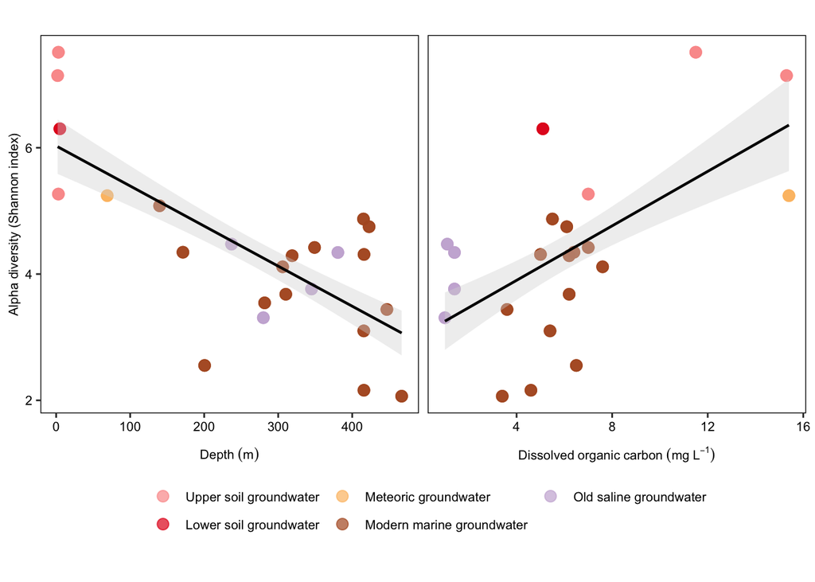

```r
chemistry %>%
  group_by(replicate, parameter) %>% summarise(value = mean(value), .groups = "drop") %>%
  filter(parameter %in% c("depth","DOC")) %>%
  inner_join(adiv, by = "replicate") %>%
  ggplot(aes(x = value, y = meandiv)) +
  geom_point(aes(color = env), size = 3, alpha = 0.7, na.rm = TRUE) +
  geom_smooth(method = "lm", formula = y ~ x,color = "black", fill = "#d9d9d9", se = TRUE, size = 0.8) +
  labs(x = "", y = 'Alpha diversity (Shannon index)') +
  scale_color_manual(values = c("#fb9a99","#e31a1c","#fdbf6f","#b15928","#cab2d6")) +
  facet_wrap(~parameter, scales = 'free_x', nrow = 1, strip.position = 'bottom', labeller =
               as_labeller(c(
                 depth = "Depth~(m)",
                 DOC = "Dissolved~organic~carbon~(mg~L^-1)"), default = label_parsed)) +
  theme_tidy() + guides(color = guide_legend(nrow = 2)) + theme(legend.box.spacing = unit(-3, 'mm'))
```

```r
ggsave("figures/fig_3bc.pdf", width = 14, height = 10, units = "cm")
```

```r
# Correlation alpha diversity and depth
chemistry %>%
  group_by(replicate, parameter) %>% summarise(value = mean(value), .groups = "drop") %>%
  filter(parameter == "depth") %>%
  inner_join(adiv, by = "replicate") %>%
  stats::cor.test(x = .$meandiv, y = .$value, method = "pearson", alternative = "two.sided")
```

```
##
##  Pearson's product-moment correlation
##
## data:  .$meandiv and .$value
## t = -8.9966, df = 70, p-value = 2.682e-13
## alternative hypothesis: true correlation is not equal to 0
## 95 percent confidence interval:
##  -0.8241376 -0.6028909
## sample estimates:
##        cor
## -0.7322811
```

```r
# Correlation alpha diversity and dissolved organic carbon
chemistry %>%
  group_by(replicate, parameter) %>% summarise(value = mean(value), .groups = "drop") %>%
  filter(parameter == "DOC") %>%
  inner_join(adiv, by = "replicate") %>%
  stats::cor.test(x = .$meandiv, y = .$value, method = "pearson", alternative = "two.sided")
```

```
##
##  Pearson's product-moment correlation
##
## data:  .$meandiv and .$value
## t = 5.9849, df = 64, p-value = 1.075e-07
## alternative hypothesis: true correlation is not equal to 0
## 95 percent confidence interval:
##  0.4175355 0.7345636
## sample estimates:
##       cor
## 0.5990318
```

```r
# Correlation alpha diversity and chloride concentration
chemistry %>%
  group_by(replicate, parameter) %>% summarise(value = mean(value), .groups = "drop") %>%
  filter(parameter == "Cl") %>%
  inner_join(adiv, by = "replicate") %>%
  stats::cor.test(x = .$meandiv, y = .$value, method = "pearson", alternative = "two.sided")
```

```
##
##  Pearson's product-moment correlation
##
## data:  .$meandiv and .$value
## t = -2.8828, df = 70, p-value = 0.005231
## alternative hypothesis: true correlation is not equal to 0
## 95 percent confidence interval:
##  -0.5183172 -0.1017785
## sample estimates:
##        cor
## -0.3257659
```

Statistical testing on alpha diversity, start with testing for the assumptions. Use the mean over the replicates (meandiv) for statistical testing.

```r
suppressPackageStartupMessages(library(car))
# Normality of the data (null hypothesis data is normally distributed)
shapiro.test(adiv$shannon)
# Homogeneity of variance using Levene (null hypothesis variance is equal)
leveneTest(shannon ~ env, data = adiv)
# Non-parametric testing (null hypothesis diversity is equal)
kruskal.test(meandiv ~ env, data = adiv)
# Run ANOVA (null hypothesis diversity is equal)
aov(meandiv ~ env, data = adiv) %>% summary()
# Post-hoc using Tukey (null hypothesis diversity is equal)
aov(meandiv ~ env, data = adiv) %>% TukeyHSD(which = "env")
```

[output not shown]

```r
seqtab %>%
  group_by(seqid) %>% filter(count > 2) %>% ungroup() %>%
  select(seqid, sample, count) %>% spread(seqid, count, fill = 0) %>%
  column_to_rownames("sample") -> t

set.seed(999)
t %>%  vegan::metaMDS(trymax = 20, k = 2, autotransform = T) -> nmds
```

Extract the scores

```r
vegan::scores(nmds) %>%
  as.data.frame() %>%
  rownames_to_column("sample") %>%
  inner_join(smd, by = "sample") -> nmds.scores
```

Plot the ordination

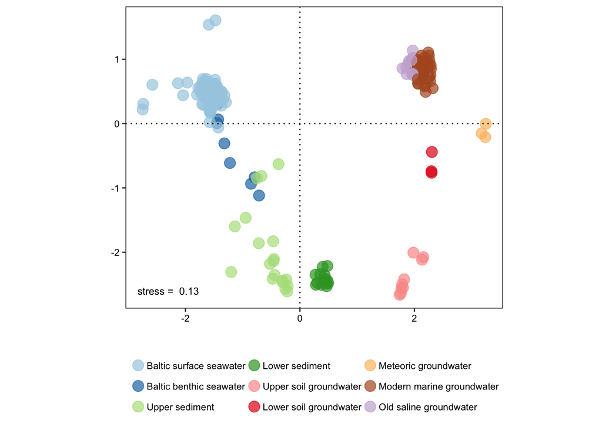

```r
nmds.scores %>%
  ggplot(aes(x = NMDS1, y = NMDS2)) +
  geom_point(aes(colour = env), size = 4.0, alpha = 0.7) +
  scale_color_manual(values =
                       c("#a6cee3","#1f78b4","#b2df8a","#33a02c",
                         "#fb9a99","#e31a1c","#fdbf6f","#b15928","#cab2d6")) +
  labs(x = "", y = "") +
  geom_vline(xintercept = 0, linetype = 'dotted') +
  geom_hline(yintercept = 0, linetype = 'dotted') +
  annotate('text', x = -2.3, y = -2.6, size = 3, label = paste('stress = ', round(nmds$stress, digits = 2))) +
  theme_tidy() + guides(color = guide_legend(nrow = 3)) +
  theme(aspect.ratio = 0.8, legend.spacing.x = unit(-0.5, 'mm'))
```

```r
ggsave("figures/fig_4.pdf", width = 12, height = 12, units = "cm")
```

```r
seqtab %>%
  filter(count > 4 & sample %in% smd[smd$surface == 'no', ]$sample) %>%
  select(seqid, sample, count) %>% spread(seqid, count, fill = 0) %>%
  column_to_rownames("sample") -> t

set.seed(99)
t %>%  vegan::metaMDS(trymax = 50, k = 2, autotransform = T) -> nmds.groundwater
```

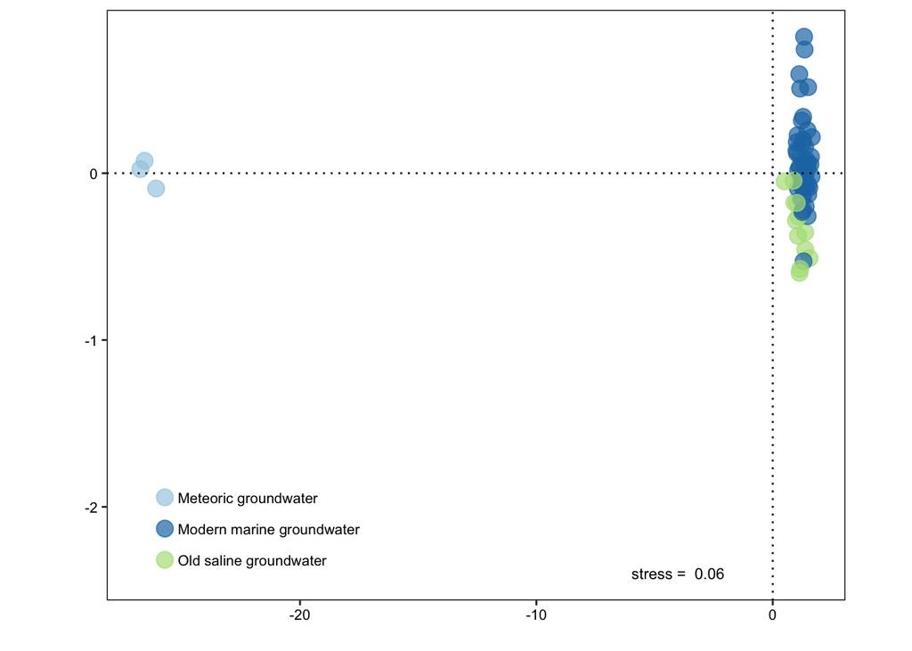

```r
vegan::scores(nmds.groundwater) %>%
  as.data.frame() %>%
  rownames_to_column("sample") %>%
  inner_join(smd, by = "sample") %>%
  ggplot(aes(x = NMDS1, y = NMDS2)) +
  geom_point(aes(colour = env), size = 4.0, alpha = 0.7) +
  scale_color_brewer(palette = 'Paired') +
  labs(x = "", y = "") +
  geom_vline(xintercept = 0, linetype = 'dotted') +
  geom_hline(yintercept = 0, linetype = 'dotted') +
  annotate('text', x = -4, y = -2.4, size = 3, label = paste('stress = ', round(nmds.groundwater$stress, digits = 2))) +
  theme_tidy() + guides(color = guide_legend(nrow = 3)) +
  theme(aspect.ratio = 0.8, legend.spacing.x = unit(-0.5, 'mm'), legend.position = c(0.20,0.13))
```

```r
ggsave("figures/fig_s4.pdf", width = 12, height = 12, units = "cm")
```

Statistical testing on beta diversity

```r
seqtab %>%
  select(-relab) %>%
  inner_join(smd[, c("sample", "env", "replicate")], by = "sample") %>%
  spread(seqid, count, fill = 0) %>%
  column_to_rownames('sample') -> df

pairwiseAdonis::pairwise.adonis2(df[,3:ncol(df)] ~ env, data = df)
```

```
## 'nperm' >= set of all permutations: complete enumeration.
```

```
## Set of permutations < 'minperm'. Generating entire set.
```

Test the homogeneity of group variation

```r
seqtab %>%
  select(-relab) %>% spread(seqid, count, fill = 0) %>%
  column_to_rownames("sample") %>%
  vegan::vegdist() %>%
  vegan::betadisper(sqrt.dist = T, group = smd %>% arrange(sample) %>% pull(env)) %>%
  anova()
```

|  | Df | Sum Sq | Mean Sq | F value | Pr(>F) |
| --- | --- | --- | --- | --- | --- |
| Groups | 8 | 0.2598246 | 0.032478074 | 6.814402 | 6.271974e-08 |
| Residuals | 205 | 0.9770491 | 0.004766093 | NA | NA |

## Bar plots

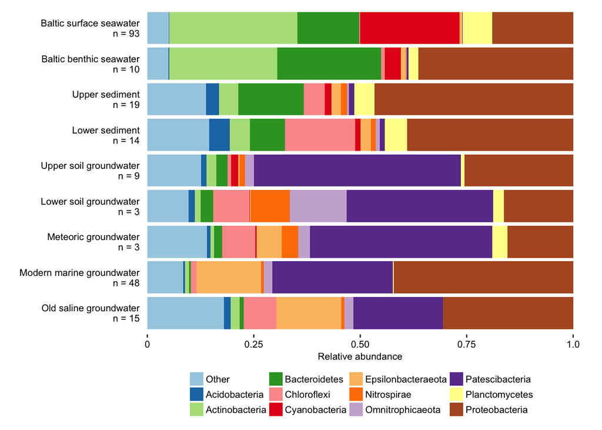

```r
x.label = smd %>% select(env, n) %>% distinct() %>% mutate(env = paste(env, n, sep = "\nn = ")) %>% pull(env)

barplot() %>%
  # Call the plot
  ggplot(aes(x = fct_rev(env), y = relab, fill = fct_relevel(topphylum, c("Other")))) +
  labs(x = '', y = 'Relative abundance') +
  geom_col() +
  scale_fill_brewer(palette = 'Paired') +
  coord_flip() +
  scale_x_discrete(labels = rev(x.label)) +
  scale_y_continuous(trans = 'reverse', labels = c('1.0','0.75','0.50','0.25','0')) +
  theme_barplot()
```

```r
ggsave("figures/fig_2a.pdf", height = 16, width = 16, units = "cm")
```

```r
barplot(taxlevel = "class") %>%
  # Call the plot
  ggplot(aes(x = fct_rev(env), y = relab, fill = fct_relevel(topphylum, c("Other")))) +
  labs(x = '', y = 'Relative abundance') +
  geom_col() +
  scale_fill_brewer(palette = 'Paired') +
  coord_flip() +
  scale_y_continuous(trans = 'reverse', labels = c('1.0','0.75','0.50','0.25','0')) +
  theme_barplot() -> fig_s3a
```

```r
my.pal <- colorRampPalette(RColorBrewer::brewer.pal(12, "Paired"))
paired.pal <- my.pal(20)

barplot(taxlevel = "order", n = 19) %>%
  mutate(topphylum = gsub("Candidatus", "Ca.", topphylum)) %>%
  # Call the plot
  ggplot(aes(x = fct_rev(env), y = relab, fill = fct_relevel(topphylum, c("Other")))) +
  labs(x = '', y = 'Relative abundance') +
  geom_col() +
  scale_fill_manual(values = paired.pal) +
  coord_flip() + scale_y_continuous(trans = 'reverse', labels = c('1.0','0.75','0.50','0.25','0')) +
  theme_barplot() -> fig_s3b
```

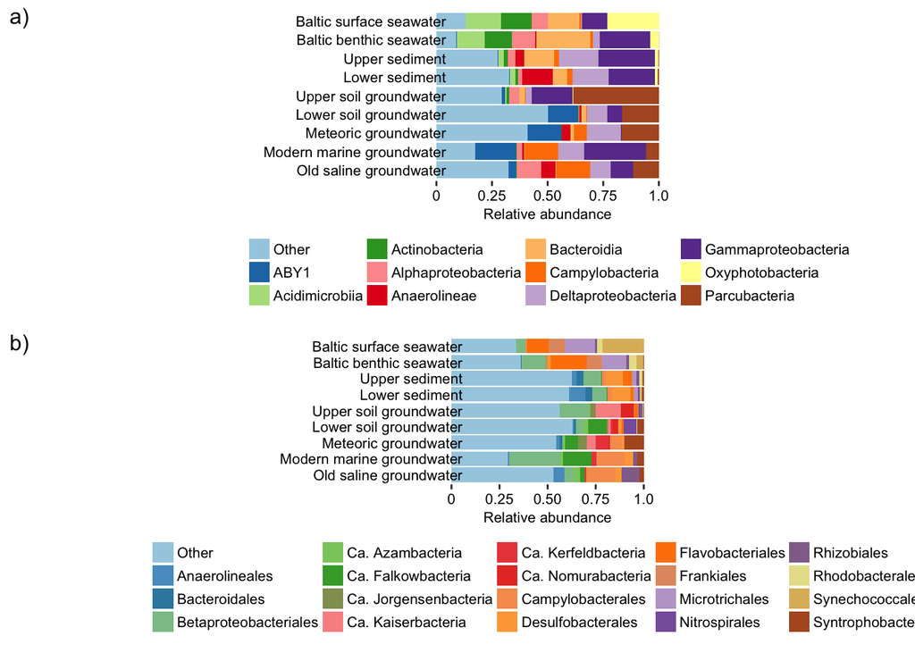

```r
cowplot::plot_grid(fig_s3a, fig_s3b, labels = c('a)','b)'), nrow = 2, label_size = 12, label_fontface = "plain")
```

```r
ggsave("figures/fig_s3.pdf", height = 20, width = 20, units = "cm")
```

## Core / unique community

The core community is defined as the ASVs that are present in each of the three groundwater types. The unique commnunity (accesory community in manuscript) are the taxa that occur in a groundwater type but are not present in the other two. By filtering “n == 3”, sequences are selected that are present in all three groundwaters; by filtering “n == 1”, only the ASVs are selected that are not present in multiple groundwaters.

```r
seqtab %>%
  # Select subsurface ASVs
  inner_join(smd, by = 'sample') %>% filter(surface == 'no') %>%
  select(seqid, env) %>%
  # Keep only unique ASVs in each environment
  distinct() %>%
  group_by(seqid) %>% add_tally() %>% ungroup() %>%
  # Require to be present in all groundwater types by stating n == 3
  mutate(community = if_else(n == 1, 'acc', 'core')) %>%
  # n == 2 is not of interest here
  filter(n != 2) %>% select(seqid, community) %>% distinct() -> core
```

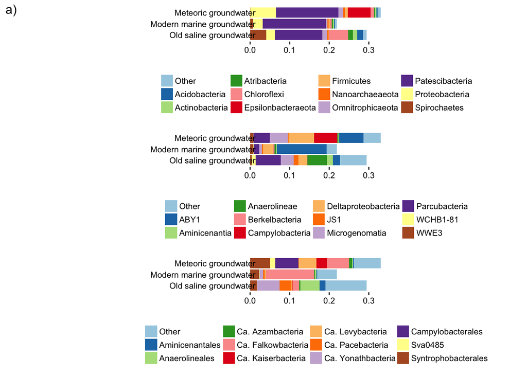

```r
seqtab %>%
  filter(seqid %in% core[core$community == 'core',]$seqid) %>%
  barplot() %>% filter(topphylum != "Other") %>%
  left_join(tax, by = c("topphylum" = "phylum")) %>% pull(seqid) -> t

seqtab %>%
  filter(seqid %in% core[core$community == 'core',]$seqid) %>%
  inner_join(tax, by = "seqid") %>%
  mutate(topphylum = if_else(seqid %in% t, phylum, "Other")) %>%
  inner_join(smd, by = 'sample') %>%
  filter(surface == 'no') %>%
  group_by(topphylum, env) %>%
  summarise(relab = sum(relab), .groups = 'drop') %>%
  ggplot(aes(x = fct_rev(env), y = relab, fill = fct_relevel(topphylum, c("Other")))) +
  labs(x = '', y = '') +
  geom_col() + scale_fill_brewer(palette = 'Paired') +
  coord_flip() + theme_barplot() + theme(aspect.ratio = 1/4) -> core.phylum

seqtab %>%
  filter(seqid %in% core[core$community == 'core',]$seqid) %>%
  barplot(taxlevel = "class") %>% filter(topphylum != "Other") %>%
  left_join(tax, by = c("topphylum" = "class")) %>% pull(seqid) -> t

seqtab %>%
  filter(seqid %in% core[core$community == 'core',]$seqid) %>%
  inner_join(tax, by = "seqid") %>%
  mutate(topphylum = if_else(seqid %in% t, class, "Other")) %>%
  inner_join(smd, by = 'sample') %>%
  filter(surface == 'no') %>%
  group_by(topphylum, env) %>%
  summarise(relab = sum(relab), .groups = 'drop') %>%
  ggplot(aes(x = fct_rev(env), y = relab, fill = fct_relevel(topphylum, c("Other")))) +
  labs(x = '', y = '') +
  geom_col() + scale_fill_brewer(palette = 'Paired') +
  coord_flip() + theme_barplot() + theme(aspect.ratio = 1/4) -> core.class

seqtab %>%
  filter(seqid %in% core[core$community == 'core',]$seqid) %>%
  barplot(taxlevel = "order") %>% filter(topphylum != "Other") %>%
  left_join(tax, by = c("topphylum" = "order")) %>% pull(seqid) -> t

seqtab %>%
  filter(seqid %in% core[core$community == 'core',]$seqid) %>%
  inner_join(tax, by = "seqid") %>%
  mutate(topphylum = if_else(seqid %in% t, order, "Other")) %>%
  inner_join(smd, by = 'sample') %>%
  filter(surface == 'no') %>%
  group_by(topphylum, env) %>%
  summarise(relab = sum(relab), .groups = 'drop') %>%
  mutate(topphylum = gsub("Candidatus", "Ca.", topphylum)) %>%
  ggplot(aes(x = fct_rev(env), y = relab, fill = fct_relevel(topphylum, c("Other")))) +
  labs(x = '', y = '') +
  geom_col() + scale_fill_brewer(palette = 'Paired') +
  coord_flip() + theme_barplot() + theme(aspect.ratio = 1/4) -> core.order

cowplot::plot_grid(core.phylum, core.class, core.order, nrow = 3, labels = c("a)", "", ""), label_fontface = "plain", label_size = 12)
```

```r
ggsave("figures/fig_s5b.pdf", width = 16, height = 18, units = "cm")
```

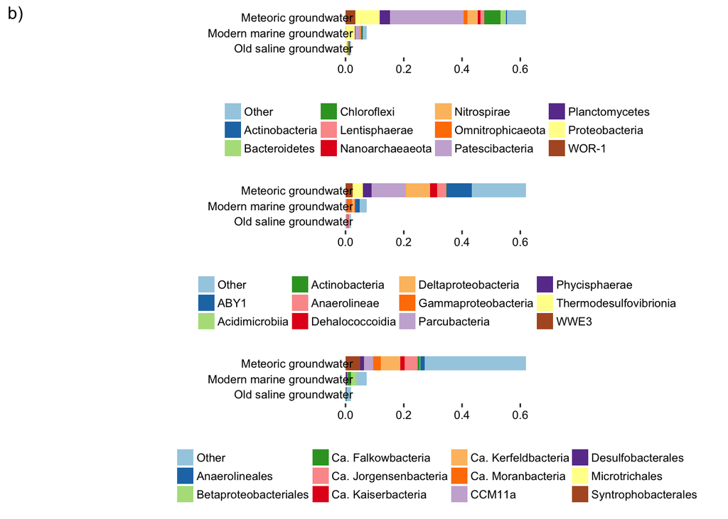

```r
seqtab %>%
  filter(seqid %in% core[core$community == 'acc',]$seqid) %>%
  barplot() %>% filter(topphylum != "Other") %>%
  left_join(tax, by = c("topphylum" = "phylum")) %>% pull(seqid) -> t

seqtab %>%
  filter(seqid %in% core[core$community == 'acc',]$seqid) %>%
  inner_join(tax, by = "seqid") %>%
  mutate(topphylum = if_else(seqid %in% t, phylum, "Other")) %>%
  inner_join(smd, by = 'sample') %>%
  filter(surface == 'no') %>%
  group_by(topphylum, env) %>%
  summarise(relab = sum(relab), .groups = 'drop') %>%
  ggplot(aes(x = fct_rev(env), y = relab, fill = fct_relevel(topphylum, c("Other")))) +
  labs(x = '', y = '') +
  geom_col() + scale_fill_brewer(palette = 'Paired') +
  coord_flip() + theme_barplot() + theme(aspect.ratio = 1/4) -> acc.phylum

seqtab %>%
  filter(seqid %in% core[core$community == 'acc',]$seqid) %>%
  barplot(taxlevel = "class") %>% filter(topphylum != "Other") %>%
  left_join(tax, by = c("topphylum" = "class")) %>% pull(seqid) -> t

seqtab %>%
  filter(seqid %in% core[core$community == 'acc',]$seqid) %>%
  inner_join(tax, by = "seqid") %>%
  mutate(topphylum = if_else(seqid %in% t, class, "Other")) %>%
  inner_join(smd, by = 'sample') %>%
  filter(surface == 'no') %>%
  group_by(topphylum, env) %>%
  summarise(relab = sum(relab), .groups = 'drop') %>%
  ggplot(aes(x = fct_rev(env), y = relab, fill = fct_relevel(topphylum, c("Other")))) +
  labs(x = '', y = '') +
  geom_col() + scale_fill_brewer(palette = 'Paired') +
  coord_flip() + theme_barplot() + theme(aspect.ratio = 1/4) -> acc.class

seqtab %>%
  filter(seqid %in% core[core$community == 'acc',]$seqid) %>%
  barplot(taxlevel = "order") %>% filter(topphylum != "Other") %>%
  left_join(tax, by = c("topphylum" = "order")) %>% pull(seqid) -> t

seqtab %>%
  filter(seqid %in% core[core$community == 'acc',]$seqid) %>%
  inner_join(tax, by = "seqid") %>%
  mutate(topphylum = if_else(seqid %in% t, order, "Other")) %>%
  inner_join(smd, by = 'sample') %>%
  filter(surface == 'no') %>%
  group_by(topphylum, env) %>%
  summarise(relab = sum(relab), .groups = 'drop') %>%
  mutate(topphylum = gsub("Candidatus", "Ca.", topphylum)) %>%
  ggplot(aes(x = fct_rev(env), y = relab, fill = fct_relevel(topphylum, c("Other")))) +
  labs(x = '', y = '') +
  geom_col() + scale_fill_brewer(palette = 'Paired') +
  coord_flip() + theme_barplot() + theme(aspect.ratio = 1/4) -> acc.order

cowplot::plot_grid(acc.phylum, acc.class, acc.order, nrow = 3, labels = c("b)", "", ""), label_fontface = "plain", label_size = 12)
```

```r
ggsave("figures/fig_s5b.pdf", width = 16, height = 18, units = "cm")
```

## Overlapping taxa

Which ASVs occur in multiple environments, also including surface environments. A small matrix is prepared containing all possible pairwise combinations between the different environments and this is piped to intersect().

```r
seqtab %>%
  # Calculate the relab within environment
  inner_join(smd, by = 'sample') %>%
  group_by(env, seqid) %>%
  summarise(relab = sum(relab), .groups = 'drop') -> reference
```

```r
expand_grid(x = unique(smd$env), y = unique(smd$env)) %>%
  mutate(overlap =
           apply(., 1, function(x) intersect(
    reference[reference$env == x[1], "seqid"],
    reference[reference$env == x[2], "seqid"]) %>% nrow())
    ) %>%
  mutate(abundance =
           apply(., 1, function(x) intersect(
    reference[reference$env == x[1], "seqid"],
    reference[reference$env == x[2], "seqid"]) %>%
      inner_join(reference, by = "seqid") %>%
      filter(env == x[1]) %>%
      pull(relab) %>%
      sum() %>%
      round(digits = 2))
  )
```

```r
seqtab %>%
  inner_join(smd, by = 'sample') %>%
  select(seqid, surface) %>% distinct() %>%
  group_by(seqid) %>% add_tally() %>% ungroup() %>%
  # By selecting n == 2, asvs are selected that are present in both surface and subsurface
  filter(n == 2) %>% pull(seqid) %>% unique() -> overlap
```

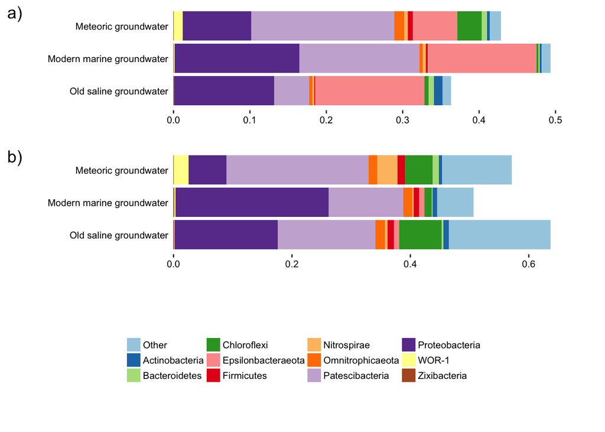

```r
seqtab %>%
  filter(seqid %in% overlap) %>%
  barplot() %>% filter(topphylum != "Other") %>%
  left_join(tax, by = c("topphylum" = "phylum")) %>% pull(seqid) -> t

seqtab %>%
  filter(seqid %in% overlap) %>%
  inner_join(tax, by = "seqid") %>%
  mutate(topphylum = if_else(seqid %in% t, phylum, "Other")) %>%
  inner_join(smd, by = 'sample') %>%
  filter(surface == 'no') %>%
  group_by(topphylum, env) %>%
  summarise(relab = sum(relab), .groups = 'drop') %>%
  ggplot(aes(x = fct_rev(env), y = relab, fill = fct_relevel(topphylum, c("Other")))) +
  labs(x = '', y = '') +
  geom_col() + scale_fill_brewer(palette = 'Paired') +
  coord_flip() + theme_barplot() + theme(aspect.ratio = 1/4) -> a

seqtab %>%
  filter(!seqid %in% overlap) %>%
  inner_join(tax, by = "seqid") %>%
  mutate(topphylum = if_else(seqid %in% t, phylum, "Other")) %>%
  inner_join(smd, by = 'sample') %>%
  filter(surface == 'no') %>%
  group_by(topphylum, env) %>%
  summarise(relab = sum(relab), .groups = 'drop') %>%
  ggplot(aes(x = fct_rev(env), y = relab, fill = fct_relevel(topphylum, c("Other")))) +
  labs(x = '', y = '') +
  geom_col() + scale_fill_brewer(palette = 'Paired') +
  coord_flip() + theme_barplot() + theme(aspect.ratio = 1/4) -> b

cowplot::plot_grid(a + theme(legend.position = 'none'), b + theme(legend.position = 'none'), cowplot::get_legend(b), nrow = 3,
                   labels = c('a)','b)'),
                   label_fontface = "plain")
```

```r
ggsave("figures/fig_5bc.pdf", height = 12, width = 16, units = "cm")
```